# Krill and Lagrangian Features

### 3. Does Krill density increase with increasing FTLE?

Here we are modelling the relationship between metrics of Krill Density within a column and FTLE for each of our four Integration lengths (24, 48, 120 and 240 Hours).

*Note: for these analyses, we are only testing the influence of FTLE on 600 meter columns that have krill.*

#### GLMM (Krill Density ~ FTLE)

For this analysis, we fit generalized linear mixed effects model using the glmmPQL package with FTLE as the independent variable and one of several metrics of Krill Density as the response variable. Krill Density is gamma distributed (positively skewed) in our dataset and we fit the model with a log-link. Our model has Year, Season and Line as random effects to account for the differences we might expect across these variables. We also included a correlation structure to account for spatial autocorrelation in our data.

##### Geometric Mean Non Zero

For every 600 meter column, we calculated the geometric mean krill density for cells within a column containing krill (i.e. For the Geometric mean, Density values were logged prior to taking the mean).

```r
## 24
# Use previously processed model to save time
if(!exists("krillDensity_gMNZGLMMPQLLogLink24")){
  krillDensity_gMNZGLMMPQLLogLink24 <- glmmPQL(KrillDensity_geoMeanNonZero ~ ftle24_L ,
                                  random = ~ 1 | Year/Season/Line,
                                  family = Gamma(link = "log"),
                                  correlation = corExp(form = ~ Long+Lat),
                                  data = dataGamm %>% dplyr::filter(!is.na(ftle24_L),KrillBiomass > 0) )
  # Save Model results to a file
  saveRDS(krillDensity_gMNZGLMMPQLLogLink24, file = "./Models/krillDensity_gMNZGLMMPQLLogLink24.rds")
}
anovagMNZGLMMPQLLogLink24 <- car::Anova(krillDensity_gMNZGLMMPQLLogLink24, type=2)

## 48
# Use previously processed model to save time
if(!exists("krillDensity_gMNZGLMMPQLLogLink48")){
  krillDensity_gMNZGLMMPQLLogLink48 <- glmmPQL(KrillDensity_geoMeanNonZero ~ ftle48_L ,
                                  random = ~ 1 | Year/Season/Line,
                                  family = Gamma(link = "log"),
                                  correlation = corExp(form = ~ Long+Lat),
                                  data = dataGamm %>% dplyr::filter(!is.na(ftle48_L),KrillBiomass > 0) )
  # Save Model results to a file
  saveRDS(krillDensity_gMNZGLMMPQLLogLink48, file = "./Models/krillDensity_gMNZGLMMPQLLogLink48.rds")
}
anovagMNZGLMMPQLLogLink48 <- car::Anova(krillDensity_gMNZGLMMPQLLogLink48, type=2)

## 120
# Use previously processed model to save time
if(!exists("krillDensity_gMNZGLMMPQLLogLink120")){
  krillDensity_gMNZGLMMPQLLogLink120 <- glmmPQL(KrillDensity_geoMeanNonZero ~ ftle120_L ,
                                  random = ~ 1 | Year/Season/Line,
                                  family = Gamma(link = "log"),
                                  correlation = corExp(form = ~ Long+Lat),
                                  data = dataGamm %>% dplyr::filter(!is.na(ftle120_L),KrillBiomass > 0) )
  # Save Model results to a file
  saveRDS(krillDensity_gMNZGLMMPQLLogLink120, file = "./Models/krillDensity_gMNZGLMMPQLLogLink120.rds")
}
anovagMNZGLMMPQLLogLink120 <- car::Anova(krillDensity_gMNZGLMMPQLLogLink120, type=2)

## 240
# Use previously processed model to save time
if(!exists("krillDensity_gMNZGLMMPQLLogLink240")){
  krillDensity_gMNZGLMMPQLLogLink240 <- glmmPQL(KrillDensity_geoMeanNonZero ~ ftle240_L,
                                  random = ~ 1 | Year/Season/Line,
                                  family = Gamma(link = "log"),
                                  correlation = corGaus(form = ~ Long+Lat),
                                  data = dataGamm %>% dplyr::filter(!is.na(ftle240_L),KrillBiomass > 0) )
  # Save Model results to a file
  saveRDS(krillDensity_gMNZGLMMPQLLogLink240, file = "./Models/krillDensity_gMNZGLMMPQLLogLink240.rds")
}
anovagMNZGLMMPQLLogLink240 <- car::Anova(krillDensity_gMNZGLMMPQLLogLink240, type=2)

tgMNZGLMMPQLLogLink <- data.frame(Model = c(rep("GLMMPQL_LogLink KrillDensity_geoMeanNonZero",4) ),
                       FTLE_Integration = c("24","48","120", "240"),
                       Slope = c(round(krillDensity_gMNZGLMMPQLLogLink24$coefficients$fixed[2],4),
                                 round(krillDensity_gMNZGLMMPQLLogLink48$coefficients$fixed[2],4),
                                 round(krillDensity_gMNZGLMMPQLLogLink120$coefficients$fixed[2],4),
                                 round(krillDensity_gMNZGLMMPQLLogLink240$coefficients$fixed[2],4)
                                 ),
                       Intercept = c(round(krillDensity_gMNZGLMMPQLLogLink24$coefficients$fixed[1],4),
                                     round(krillDensity_gMNZGLMMPQLLogLink48$coefficients$fixed[1],4),
                                     round(krillDensity_gMNZGLMMPQLLogLink120$coefficients$fixed[1],4),
                                     round(krillDensity_gMNZGLMMPQLLogLink240$coefficients$fixed[1],4)
                                 ),
                       pValue = c(round(anovagMNZGLMMPQLLogLink24$`Pr(>Chisq)`,5),
                                  round(anovagMNZGLMMPQLLogLink48$`Pr(>Chisq)`,5),
                                  round(anovagMNZGLMMPQLLogLink120$`Pr(>Chisq)`,5),
                                  round(anovagMNZGLMMPQLLogLink240$`Pr(>Chisq)`,5)
                                  )
)
tgMNZGLMMPQLLogLink
```

|  | Model | FTLE_Integration | Slope | Intercept | pValue |
| --- | --- | --- | --- | --- | --- |
| ftle24_L | GLMMPQL_LogLink KrillDensity_geoMeanNonZero | 24 | 0.2731 | 0.8225 | 0.08437 |
| ftle48_L | GLMMPQL_LogLink KrillDensity_geoMeanNonZero | 48 | 0.3622 | 0.8165 | 0.05616 |
| ftle120_L | GLMMPQL_LogLink KrillDensity_geoMeanNonZero | 120 | 0.8218 | 0.8196 | 0.00110 |
| ftle240_L | GLMMPQL_LogLink KrillDensity_geoMeanNonZero | 240 | 0.9878 | 0.7580 | 0.00061 |

##### Mean Non Zero

For every 600 meter column, we calculated the mean krill density for cells within a column containing krill (i.e. Mean Non-Zero).

```r
## 24
# Use previously processed model to save time
if(!exists("krillDensity_MNZGLMMPQLLogLink24")){
  krillDensity_MNZGLMMPQLLogLink24 <- glmmPQL(KrillDensity_MeanNonZero ~ ftle24_L ,
                                  random = ~ 1 | Year/Season/Line,
                                  family = Gamma(link = "log"),
                                  correlation = corExp(form = ~ Long+Lat),
                                  data = dataGamm %>% dplyr::filter(!is.na(ftle24_L),KrillBiomass > 0) )
  # Save Model results to a file
  saveRDS(krillDensity_MNZGLMMPQLLogLink24, file = "./Models/krillDensity_MNZGLMMPQLLogLink24.rds")
}
anovaMNZGLMMPQLLogLink24 <- car::Anova(krillDensity_MNZGLMMPQLLogLink24, type=2)

## 48
# Use previously processed model to save time
if(!exists("krillDensity_MNZGLMMPQLLogLink48")){
  krillDensity_MNZGLMMPQLLogLink48 <- glmmPQL(KrillDensity_MeanNonZero ~ ftle48_L ,
                                  random = ~ 1 | Year/Season/Line,
                                  family = Gamma(link = "log"),
                                  correlation = corExp(form = ~ Long+Lat),
                                  data = dataGamm %>% dplyr::filter(!is.na(ftle48_L),KrillBiomass > 0) )
  # Save Model results to a file
  saveRDS(krillDensity_MNZGLMMPQLLogLink48, file = "./Models/krillDensity_MNZGLMMPQLLogLink48.rds")
}
anovaMNZGLMMPQLLogLink48 <- car::Anova(krillDensity_MNZGLMMPQLLogLink48, type=2)

## 120
# Use previously processed model to save time
if(!exists("krillDensity_MNZGLMMPQLLogLink120")){
  krillDensity_MNZGLMMPQLLogLink120 <- glmmPQL(KrillDensity_MeanNonZero ~ ftle120_L ,
                                  random = ~ 1 | Year/Season/Line,
                                  family = Gamma(link = "log"),
                                  correlation = corExp(form = ~ Long+Lat),
                                  data = dataGamm %>% dplyr::filter(!is.na(ftle120_L),KrillBiomass > 0) )
  # Save Model results to a file
  saveRDS(krillDensity_MNZGLMMPQLLogLink120, file = "./Models/krillDensity_MNZGLMMPQLLogLink120.rds")
}
anovaMNZGLMMPQLLogLink120 <- car::Anova(krillDensity_MNZGLMMPQLLogLink120, type=2)

## 240
# Use previously processed model to save time
if(!exists("krillDensity_MNZGLMMPQLLogLink240")){
  krillDensity_MNZGLMMPQLLogLink240 <- glmmPQL(KrillDensity_MeanNonZero ~ ftle240_L ,
                                  random = ~ 1 | Year/Season/Line,
                                  family = Gamma(link = "log"),
                                  correlation = corExp(form = ~ Long+Lat),
                                  data = dataGamm %>% dplyr::filter(!is.na(ftle240_L),KrillBiomass > 0) )
  # Save Model results to a file
  saveRDS(krillDensity_MNZGLMMPQLLogLink240, file = "./Models/krillDensity_MNZGLMMPQLLogLink240.rds")
}
anovaMNZGLMMPQLLogLink240 <- car::Anova(krillDensity_MNZGLMMPQLLogLink240, type=2)

tMNZGLMMPQLLogLink <- data.frame(Model = c(rep("GLMMPQL_LogLink KrillDensity_MeanNonZero",4) ),
                       FTLE_Integration = c("24","48","120", "240"),
                       Slope = c(round(krillDensity_MNZGLMMPQLLogLink24$coefficients$fixed[2],4),
                                 round(krillDensity_MNZGLMMPQLLogLink48$coefficients$fixed[2],4),
                                 round(krillDensity_MNZGLMMPQLLogLink120$coefficients$fixed[2],4),
                                 round(krillDensity_MNZGLMMPQLLogLink240$coefficients$fixed[2],4)
                                 ),
                       Intercept = c(round(krillDensity_MNZGLMMPQLLogLink24$coefficients$fixed[1],4),
                                     round(krillDensity_MNZGLMMPQLLogLink48$coefficients$fixed[1],4),
                                     round(krillDensity_MNZGLMMPQLLogLink120$coefficients$fixed[1],4),
                                     round(krillDensity_MNZGLMMPQLLogLink240$coefficients$fixed[1],4)
                                 ),
                       pValue = c(round(anovaMNZGLMMPQLLogLink24$`Pr(>Chisq)`,5),
                                  round(anovaMNZGLMMPQLLogLink48$`Pr(>Chisq)`,5),
                                  round(anovaMNZGLMMPQLLogLink120$`Pr(>Chisq)`,5),
                                  round(anovaMNZGLMMPQLLogLink240$`Pr(>Chisq)`,5)
                                  )
)
tMNZGLMMPQLLogLink
```

|  | Model | FTLE_Integration | Slope | Intercept | pValue |
| --- | --- | --- | --- | --- | --- |
| ftle24_L | GLMMPQL_LogLink KrillDensity_MeanNonZero | 24 | 0.2064 | 1.1619 | 0.18788 |
| ftle48_L | GLMMPQL_LogLink KrillDensity_MeanNonZero | 48 | 0.4448 | 1.1128 | 0.01664 |
| ftle120_L | GLMMPQL_LogLink KrillDensity_MeanNonZero | 120 | 0.9310 | 1.1037 | 0.00016 |
| ftle240_L | GLMMPQL_LogLink KrillDensity_MeanNonZero | 240 | 0.9675 | 1.1212 | 0.00248 |

##### Max Density

For every 600 meter column, we calculated the maximum krill density for cells containing krill.

```r
## 24
# Use previously processed model to save time
if(!exists("krillDensity_MaxGLMMPQLLogLink24")){
  krillDensity_MaxGLMMPQLLogLink24 <- glmmPQL(KrillDensity_Max ~ ftle24_L ,
                                  random = ~ 1 | Year/Season/Line,
                                  family = Gamma(link = "log"),
                                  correlation = corExp(form = ~ Long+Lat),
                                  data = dataGamm %>% dplyr::filter(!is.na(ftle24_L),KrillBiomass > 0) )
  # Save Model results to a file
  saveRDS(krillDensity_MaxGLMMPQLLogLink24, file = "./Models/krillDensity_MaxGLMMPQLLogLink24.rds")
}
anovaMaxGLMMPQLLogLink24 <- car::Anova(krillDensity_MaxGLMMPQLLogLink24, type=2)

## 48
# Use previously processed model to save time
if(!exists("krillDensity_MaxGLMMPQLLogLink48")){
  krillDensity_MaxGLMMPQLLogLink48 <- glmmPQL(KrillDensity_Max ~ ftle48_L ,
                                  random = ~ 1 | Year/Season/Line,
                                  family = Gamma(link = "log"),
                                  correlation = corExp(form = ~ Long+Lat),
                                  data = dataGamm %>% dplyr::filter(!is.na(ftle48_L),KrillBiomass > 0) )
  # Save Model results to a file
  saveRDS(krillDensity_MaxGLMMPQLLogLink48, file = "./Models/krillDensity_MaxGLMMPQLLogLink48.rds")
}
anovaMaxGLMMPQLLogLink48 <- car::Anova(krillDensity_MaxGLMMPQLLogLink48, type=2)

## 120
# Use previously processed model to save time
if(!exists("krillDensity_MaxGLMMPQLLogLink120")){
  krillDensity_MaxGLMMPQLLogLink120 <- glmmPQL(KrillDensity_Max ~ ftle120_L ,
                                  random = ~ 1 | Year/Season/Line,
                                  family = Gamma(link = "log"),
                                  correlation = corExp(form = ~ Long+Lat),
                                  data = dataGamm %>% dplyr::filter(!is.na(ftle120_L),KrillBiomass > 0) )
  # Save Model results to a file
  saveRDS(krillDensity_MaxGLMMPQLLogLink120, file = "./Models/krillDensity_MaxGLMMPQLLogLink120.rds")
}
anovaMaxGLMMPQLLogLink120 <- car::Anova(krillDensity_MaxGLMMPQLLogLink120, type=2)

## 240
# Use previously processed model to save time
if(!exists("krillDensity_MaxGLMMPQLLogLink240")){
  krillDensity_MaxGLMMPQLLogLink240 <- glmmPQL(KrillDensity_Max ~ ftle240_L ,
                                  random = ~ 1 | Year/Season/Line,
                                  family = Gamma(link = "log"),
                                  correlation = corExp(form = ~ Long+Lat),
                                  data = dataGamm %>% dplyr::filter(!is.na(ftle240_L),KrillBiomass > 0) )
  # Save Model results to a file
  saveRDS(krillDensity_MaxGLMMPQLLogLink240, file = "./Models/krillDensity_MaxGLMMPQLLogLink240.rds")
}
anovaMaxGLMMPQLLogLink240 <- car::Anova(krillDensity_MaxGLMMPQLLogLink240, type=2)

tMaxGLMMPQLLogLink <- data.frame(Model = c(rep("GLMMPQL_LogLink KrillDensity_Max",4) ),
                       FTLE_Integration = c("24","48","120", "240"),
                       Slope = c(round(krillDensity_MaxGLMMPQLLogLink24$coefficients$fixed[2],4),
                                 round(krillDensity_MaxGLMMPQLLogLink48$coefficients$fixed[2],4),
                                 round(krillDensity_MaxGLMMPQLLogLink120$coefficients$fixed[2],4),
                                 round(krillDensity_MaxGLMMPQLLogLink240$coefficients$fixed[2],4)
                                 ),
                       Intercept = c(round(krillDensity_MaxGLMMPQLLogLink24$coefficients$fixed[1],4),
                                     round(krillDensity_MaxGLMMPQLLogLink48$coefficients$fixed[1],4),
                                     round(krillDensity_MaxGLMMPQLLogLink120$coefficients$fixed[1],4),
                                     round(krillDensity_MaxGLMMPQLLogLink240$coefficients$fixed[1],4)
                                 ),
                       pValue = c(round(anovaMaxGLMMPQLLogLink24$`Pr(>Chisq)`,5),
                                  round(anovaMaxGLMMPQLLogLink48$`Pr(>Chisq)`,5),
                                  round(anovaMaxGLMMPQLLogLink120$`Pr(>Chisq)`,5),
                                  round(anovaMaxGLMMPQLLogLink240$`Pr(>Chisq)`,5)
                                  )
)
tMaxGLMMPQLLogLink
```

|  | Model | FTLE_Integration | Slope | Intercept | pValue |
| --- | --- | --- | --- | --- | --- |
| ftle24_L | GLMMPQL_LogLink KrillDensity_Max | 24 | 0.0676 | 1.9669 | 0.68640 |
| ftle48_L | GLMMPQL_LogLink KrillDensity_Max | 48 | 0.4069 | 1.8880 | 0.04000 |
| ftle120_L | GLMMPQL_LogLink KrillDensity_Max | 120 | 0.8840 | 1.8287 | 0.00085 |
| ftle240_L | GLMMPQL_LogLink KrillDensity_Max | 240 | 0.8341 | 1.8129 | 0.01589 |

##### Supplemental Figure 3

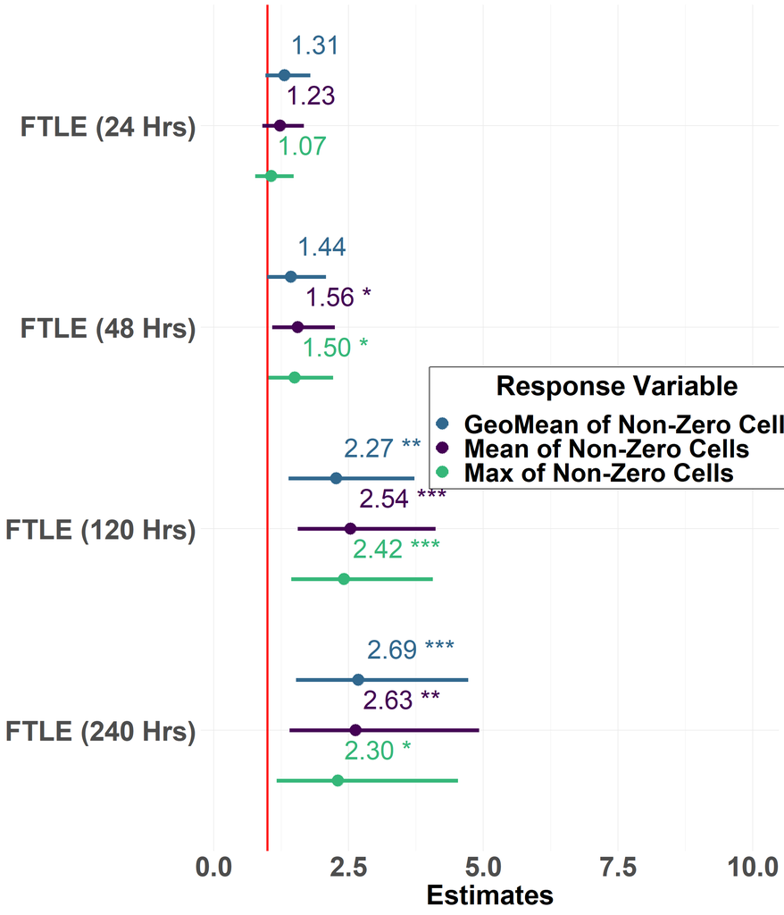

```r
  p_DensityAll <- plot_models(krillDensity_MaxGLMMPQLLogLink24,krillDensity_MaxGLMMPQLLogLink48,
                              krillDensity_MaxGLMMPQLLogLink120,krillDensity_MaxGLMMPQLLogLink240,
                              krillDensity_MNZGLMMPQLLogLink24,krillDensity_MNZGLMMPQLLogLink48,
                              krillDensity_MNZGLMMPQLLogLink120,krillDensity_MNZGLMMPQLLogLink240,
                              krillDensity_gMNZGLMMPQLLogLink24,krillDensity_gMNZGLMMPQLLogLink48,
                              krillDensity_gMNZGLMMPQLLogLink120,krillDensity_gMNZGLMMPQLLogLink240,
                              vline.color = "red",show.p=TRUE,show.values=TRUE, spacing = .75,
                              #axis.lim = c(0.75,7.5),
                              show.legend = TRUE, dot.size = 6, value.size = 10, line.size = 2,
                              axis.labels = c("FTLE (240 Hrs)","FTLE (120 Hrs)","FTLE (48 Hrs)","FTLE (24 Hrs)")) +
    # ggtitle("Metrics of Krill Density ~ FTLE", subtitle = "glmmPQL Log-Link with Spatial Autocorrelation Structure")+
    ylim(0.25,10)+
    theme_minimal() +
    theme(axis.title = element_text(face="bold", size=30),
          axis.text = element_text( face="bold", size=30),
          plot.title = element_text(face="bold", size=25,hjust = 0.5),
          plot.subtitle = element_text( face="bold", size=20,hjust = 0.5),
          plot.caption = element_text( face="bold", size=12,hjust = 0),
          legend.position = c(0.72,0.5),
          legend.direction = "vertical",
          legend.background = element_rect(fill="white",color="black"),
          legend.text = element_text(face="bold", size=28),
          legend.title = element_text(face="bold", size=30, hjust = 0.5))

  p_DensityAll$guides$colour$title <- "Response Variable"
  p_DensityAll$data$group <- factor(x = c(rep("Max of Non-Zero Cells",4), rep("Mean of Non-Zero Cells",4), rep("GeoMean of Non-Zero Cells",4)),
                                    levels = c( "Max of Non-Zero Cells", "Mean of Non-Zero Cells","GeoMean of Non-Zero Cells") )
  p_DensityAll <- p_DensityAll + scale_color_manual(breaks=c( "Max of Non-Zero Cells",
                                                              "Mean of Non-Zero Cells" ,
                                                              "GeoMean of Non-Zero Cells"),
                                                    values=c( "Mean of Non-Zero Cells" =  "#440154FF",
                                                              "GeoMean of Non-Zero Cells" =  "#31688EFF",
                                                              "Max of Non-Zero Cells" =  "#35B779FF"
  ) )
  p_DensityAll
```

##### Figure 3B

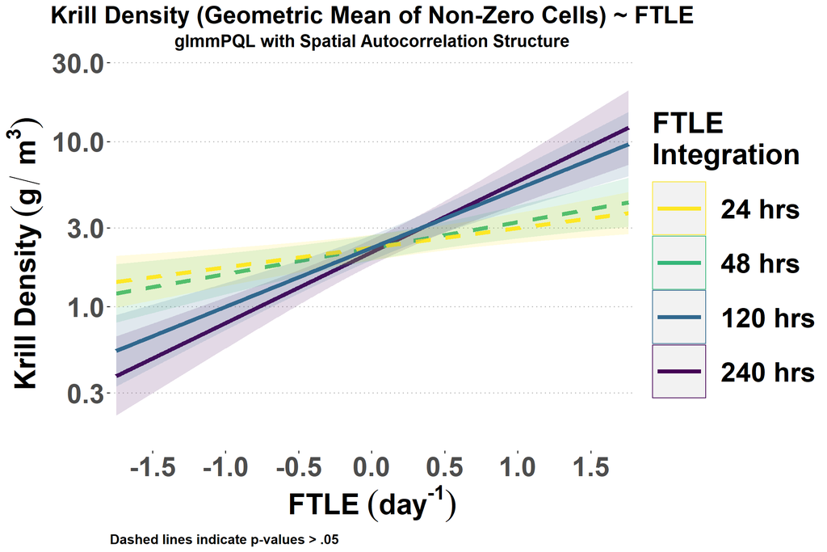

```r
testSetp24 <- data.frame(ftle24_L = seq(-2, 2, length.out = 1000))
# This function outputs the predicted values in Response scale
testSetp24$fit <- predict(krillDensity_gMNZGLMMPQLLogLink24,testSetp24, type = "response", level=0)
# This function outputs the predicted SE values in Log scale
SE_p24 <- predictSE(krillDensity_gMNZGLMMPQLLogLink24,testSetp24, type = "response", level = 0,se.fit = TRUE)
# Convert the Log Standard errors into the Response scale
testSetp24$lwr <- exp(SE_p24$fit-SE_p24$se.fit)
testSetp24$upr <- exp(SE_p24$fit+SE_p24$se.fit)
testSetp24$model <- "24 hrs"

testSetp48 <- data.frame(ftle48_L = seq(-2, 2, length.out = 1000))
# This function outputs the predicted values in Response scale
testSetp48$fit <- predict(krillDensity_gMNZGLMMPQLLogLink48,testSetp48, type = "response", level=0)
# This function outputs the predicted SE values in Log scale
SE_p48 <- predictSE(krillDensity_gMNZGLMMPQLLogLink48,testSetp48, type = "response", level = 0,se.fit = TRUE)
# Convert the Log Standard errors into the Response scale
testSetp48$lwr <- exp(SE_p48$fit-SE_p48$se.fit)
testSetp48$upr <- exp(SE_p48$fit+SE_p48$se.fit)
testSetp48$model <- "48 hrs"

testSetp120 <- data.frame(ftle120_L = seq(-2, 2, length.out = 1000))
# This function outputs the predicted values in Response scale
testSetp120$fit <- predict(krillDensity_gMNZGLMMPQLLogLink120,testSetp120, type = "response", level=0)
# This function outputs the predicted SE values in Log scale
SE_p120 <- predictSE(krillDensity_gMNZGLMMPQLLogLink120,testSetp120, type = "response", level = 0,se.fit = TRUE)
# Convert the Log Standard errors into the Response scale
testSetp120$lwr <- exp(SE_p120$fit-SE_p120$se.fit)
testSetp120$upr <- exp(SE_p120$fit+SE_p120$se.fit)
testSetp120$model <- "120 hrs"

testSetp240 <- data.frame(ftle240_L = seq(-2, 2, length.out = 1000))
# This function outputs the predicted values in Response scale
testSetp240$fit <- predict(krillDensity_gMNZGLMMPQLLogLink240,testSetp240, type = "response", level=0)
# This function outputs the predicted SE values in Log scale
SE_p240 <- predictSE(krillDensity_gMNZGLMMPQLLogLink240,testSetp240, type = "response", level = 0,se.fit = TRUE)
# Convert the Log Standard errors into the Response scale
testSetp240$lwr <- exp(SE_p240$fit-SE_p240$se.fit)
testSetp240$upr <- exp(SE_p240$fit+SE_p240$se.fit)
testSetp240$model <- "240 hrs"

ggplot() +
  geom_ribbon(data=testSetp240,aes(x=ftle240_L,ymin = lwr, ymax = upr, color = NULL,fill=model), alpha = .15) +
  geom_line(data=testSetp240,aes(x=ftle240_L,y = fit, color=model), size = 2, linetype=1)+
  geom_ribbon(data=testSetp48,aes(x=ftle48_L,ymin = lwr, ymax = upr, color = NULL,fill=model), alpha = .15) +
  geom_line(data=testSetp48,aes(x=ftle48_L,y = fit, color=model), size = 2, linetype=2)+
  geom_ribbon(data=testSetp24,aes(x=ftle24_L,ymin = lwr, ymax = upr, color = NULL,fill=model), alpha = .15) +
  geom_line(data=testSetp24,aes(x=ftle24_L,y = fit, color=model), size = 2, linetype=2)+
  geom_ribbon(data=testSetp120,aes(x=ftle120_L,ymin = lwr, ymax = upr, color = NULL,fill=model), alpha = .15) +
  geom_line(data=testSetp120,aes(x=ftle120_L,y = fit, color=model), size = 2, linetype=1)+
  scale_color_manual(name= "FTLE\nIntegration",
                       breaks=c("24 hrs","48 hrs","120 hrs","240 hrs"),
                       values=c( "24 hrs" =     "#FDE725FF",
                               "48 hrs" = "#35B779FF",
                               "120 hrs" =  "#31688EFF",
                               "240 hrs" = "#440154FF"
                               )) +
  scale_fill_manual(name= "FTLE\nIntegration",
                      breaks=c("24 hrs","48 hrs","120 hrs","240 hrs"),
                       values=c( "24 hrs" =     "#FDE725FF",
                               "48 hrs" = "#35B779FF",
                               "120 hrs" =  "#31688EFF",
                               "240 hrs" = "#440154FF"
                               )) +
  scale_x_continuous(breaks=seq(-1.5,2,.5),limits=c(-1.75,1.76), expand = c(0.005, 0.025))+
  scale_y_log10(expand = c(0.0000000001,0.075)
  )+
  ylab(expression( bold(Krill~Density~(g/~m^{bold("3")})))) +    #Krill Density (g/m^3)
  xlab(expression( bold(FTLE~(day^bold({bold("-1")})))) )+
  guides(fill = guide_legend(order=1,override.aes = list(alpha=0.25, linetype=1)),
         color = guide_legend(order=1,override.aes = list(alpha=1, linetype=1,fill=NA))
         )+
  labs(caption = "Dashed lines indicate p-values > .05") +
  ggtitle("Krill Density (Geometric Mean of Non-Zero Cells) ~ FTLE",subtitle = "glmmPQL with Spatial Autocorrelation Structure") +
  theme_pubclean()+
  theme(axis.title = element_text(face="bold", size=30),
        axis.text = element_text( face="bold", size=28),
        plot.title = element_text(face="bold", size=25,hjust = 0.5),
        plot.subtitle = element_text( face="bold", size=18,hjust = 0.5),
        plot.caption = element_text( face="bold", size=14,hjust = 0),
        legend.position="right",
        legend.text = element_text(face="bold", size=28),
        legend.title = element_text(face="bold", size=30),
        legend.key.size = unit(2,"cm"),
        strip.text.x = element_text(size = 22, face="bold"))
```

## FTLE and Cetacean Sightings

### 4. Are Cetacean sightings more likely in areas with higher FTLE?

#### GLMM (Whale Presence ~ FTLE)

##### Blue Whale Sightings

The relationship between the likelihood of blue whale presence and FTLE is explored using a linear mixed-effects model. Here we are using a logistic regression to test the probability of blue whale presence across a range of FTLE values for each of the 4 integration times.

```r
# Use previously processed model to save time
if(!exists("bw_glmmPQL_24_Hrs")){
  bw_glmmPQL_24_Hrs <- glmmPQL(BLWH ~ ftle24_L ,
                                random = ~ 1 | Year/Season/Line,
                                family = binomial(link = "logit"),
                                data = dataGamm %>% dplyr::filter(!is.na(ftle24_L)))
}

# Use previously processed model to save time
if(!exists("bw_glmmPQL_48_Hrs")){
  bw_glmmPQL_48_Hrs <- glmmPQL(BLWH ~ ftle48_L,
                                random = ~ 1 | Year/Season/Line,
                                family = binomial(link = "logit"),
                                data = dataGamm %>% dplyr::filter(!is.na(ftle48_L)))
}

# Use previously processed model to save time
if(!exists("bw_glmmPQL_120_Hrs")){
  bw_glmmPQL_120_Hrs <- glmmPQL(BLWH ~ ftle120_L,
                                random = ~ 1 | Year/Season/Line,
                                family = binomial(link = "logit"),
                                data = dataGamm %>% dplyr::filter(!is.na(ftle120_L)))
}

# Use previously processed model to save time
if(!exists("bw_glmmPQL_240_Hrs")){
  bw_glmmPQL_240_Hrs <- glmmPQL(BLWH ~ ftle240_L,
                                random = ~ 1 | Year/Season/Line,
                                family = binomial(link = "logit"),
                                data = dataGamm %>% dplyr::filter(!is.na(ftle240_L)))
}

cat(paste0("bw_glmmPQL_24_Hrs: ",  "Slope: ",
           round(as.data.frame(coef(summary(bw_glmmPQL_24_Hrs)))$Value[2],3), ", p-value: ",
           round(as.data.frame(coef(summary(bw_glmmPQL_24_Hrs)))$'p-value'[2],4)))
## bw_glmmPQL_24_Hrs: Slope: 0.786, p-value: 0.0069

tBW <- data.frame(Model = rep("BLWH Presence ~ FTLE",4),
                  FTLE_Integration = c("24","48","120", "240"),
                  Slope =
                    c(round(as.data.frame(coef(summary(bw_glmmPQL_24_Hrs)))$Value[2],3),
                      round(as.data.frame(coef(summary(bw_glmmPQL_48_Hrs)))$Value[2],3),
                      round(as.data.frame(coef(summary(bw_glmmPQL_120_Hrs)))$Value[2],3),
                      round(as.data.frame(coef(summary(bw_glmmPQL_240_Hrs)))$Value[2],3)
                      ),
                  Intercept =
                    c(round(as.data.frame(coef(summary(bw_glmmPQL_24_Hrs)))$Value[1],3),
                      round(as.data.frame(coef(summary(bw_glmmPQL_48_Hrs)))$Value[1],3),
                      round(as.data.frame(coef(summary(bw_glmmPQL_120_Hrs)))$Value[1],3),
                      round(as.data.frame(coef(summary(bw_glmmPQL_240_Hrs)))$Value[1],3)
                      ),
                  pValue =
                    c(round(as.data.frame(coef(summary(bw_glmmPQL_24_Hrs)))$'p-value'[2],5),
                      round(as.data.frame(coef(summary(bw_glmmPQL_48_Hrs)))$'p-value'[2],5),
                      round(as.data.frame(coef(summary(bw_glmmPQL_120_Hrs)))$'p-value'[2],5),
                      round(as.data.frame(coef(summary(bw_glmmPQL_240_Hrs)))$'p-value'[2],5)
                      )
  )
tBW
```

| Model | FTLE_Integration | Slope | Intercept | pValue |
| --- | --- | --- | --- | --- |
| BLWH Presence ~ FTLE | 24 | 0.786 | -5.920 | 0.00686 |
| BLWH Presence ~ FTLE | 48 | 1.339 | -5.991 | 0.00007 |
| BLWH Presence ~ FTLE | 120 | 1.200 | -5.828 | 0.01009 |
| BLWH Presence ~ FTLE | 240 | 2.116 | -5.975 | 0.00077 |

##### Figure 3C

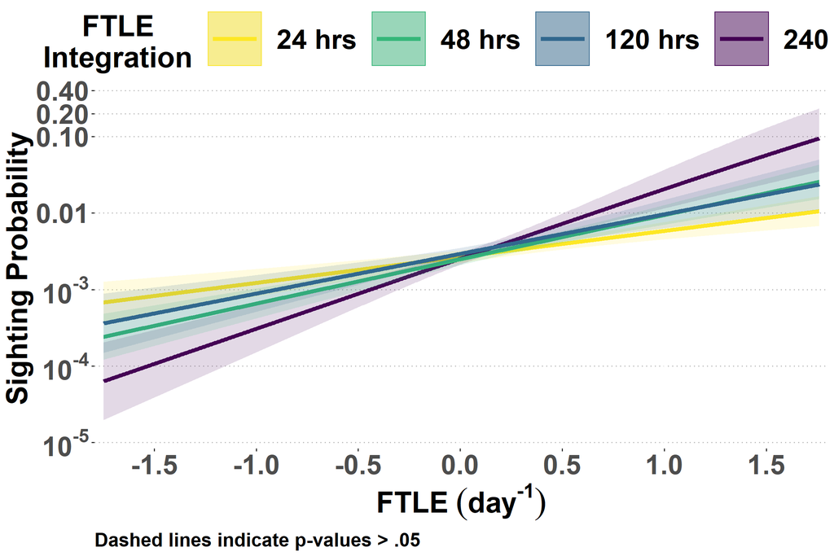

```r
testSet_bw_p24 <- data.frame(ftle24_L = seq(-2, 2, length.out = 1000))
# This function outputs the predicted values in probability space
testSet_bw_p24$fit <- predict(bw_glmmPQL_24_Hrs,testSet_bw_p24, type = "response", level=0)

# This function outputs the predicted values in Logit space
SE_p24 <- predictSE(bw_glmmPQL_24_Hrs,testSet_bw_p24, type = "response", level = 0,se.fit = TRUE)
# Convert the Logit Standard errors into Probabilities
testSet_bw_p24$lwr <- logit2prob(SE_p24$fit-SE_p24$se.fit)
testSet_bw_p24$upr <- logit2prob(SE_p24$fit+SE_p24$se.fit)
testSet_bw_p24$model <- "24 hrs"

testSet_bw_p48 <- data.frame(ftle48_L = seq(-2, 2, length.out = 1000))
# This function outputs the predicted values in probability space
testSet_bw_p48$fit <- predict(bw_glmmPQL_48_Hrs,testSet_bw_p48, type = "response", level=0)
# This function outputs the predicted values in Logit space
SE_p48 <- predictSE(bw_glmmPQL_48_Hrs,testSet_bw_p48, type = "response", level = 0,se.fit = TRUE)
# Convert the Logit Standard errors into Probabilities
testSet_bw_p48$lwr <- logit2prob(SE_p48$fit-SE_p48$se.fit)
testSet_bw_p48$upr <- logit2prob(SE_p48$fit+SE_p48$se.fit)
testSet_bw_p48$model <- "48 hrs"

testSet_bw_p120 <- data.frame(ftle120_L = seq(-2, 2, length.out = 1000))
# This function outputs the predicted values in probability space
testSet_bw_p120$fit <- predict(bw_glmmPQL_120_Hrs,testSet_bw_p120, type = "response", level=0)
# This function outputs the predicted values in Logit space
SE_p120 <- predictSE(bw_glmmPQL_120_Hrs,testSet_bw_p120, type = "response", level = 0,se.fit = TRUE)
# Convert the Logit Standard errors into Probabilities
testSet_bw_p120$lwr <- logit2prob(SE_p120$fit-SE_p120$se.fit)
testSet_bw_p120$upr <- logit2prob(SE_p120$fit+SE_p120$se.fit)
testSet_bw_p120$model <- "120 hrs"

testSet_bw_p240 <- data.frame(ftle240_L = seq(-2, 2, length.out = 1000))
# This function outputs the predicted values in probability space
testSet_bw_p240$fit <- predict(bw_glmmPQL_240_Hrs,testSet_bw_p240, type = "response", level=0)
# This function outputs the predicted values in Logit space
SE_p240 <- predictSE(bw_glmmPQL_240_Hrs,testSet_bw_p240, type = "response", level = 0,se.fit = TRUE)
# Convert the Logit Standard errors into Probabilities
testSet_bw_p240$lwr <- logit2prob(SE_p240$fit-SE_p240$se.fit)
testSet_bw_p240$upr <- logit2prob(SE_p240$fit+SE_p240$se.fit)
testSet_bw_p240$model <- "240 hrs"

ggplot() +
  geom_ribbon(data=testSet_bw_p24,aes(x=ftle24_L,ymin = lwr, ymax = upr, color = NULL,fill=model), alpha = .15) +
  geom_line(data=testSet_bw_p24,aes(x=ftle24_L,y = fit, color=model), size = 2, linetype=1)+
  geom_ribbon(data=testSet_bw_p240,aes(x=ftle240_L,ymin = lwr, ymax = upr, color = NULL,fill=model), alpha = .15) +
  geom_line(data=testSet_bw_p240,aes(x=ftle240_L,y = fit, color=model), size = 2, linetype=1)+
  geom_ribbon(data=testSet_bw_p48,aes(x=ftle48_L,ymin = lwr, ymax = upr, color = NULL,fill=model), alpha = .15) +
  geom_line(data=testSet_bw_p48,aes(x=ftle48_L,y = fit, color=model), size = 2, linetype=1)+

  geom_ribbon(data=testSet_bw_p120,aes(x=ftle120_L,ymin = lwr, ymax = upr, color = NULL,fill=model), alpha = .15) +
  geom_line(data=testSet_bw_p120,aes(x=ftle120_L,y = fit, color=model), size = 2, linetype=1)+
 scale_color_manual(name= "FTLE\nIntegration",
                       breaks=c("24 hrs","48 hrs","120 hrs","240 hrs"),
                       values=c( "24 hrs" =     "#FDE725FF",
                               "48 hrs" = "#35B779FF",
                               "120 hrs" =  "#31688EFF",
                               "240 hrs" = "#440154FF"
                               )) +
  scale_fill_manual(name= "FTLE\nIntegration",
                      breaks=c("24 hrs","48 hrs","120 hrs","240 hrs"),
                       values=c( "24 hrs" =     "#FDE725FF",
                               "48 hrs" = "#35B779FF",
                               "120 hrs" =  "#31688EFF",
                               "240 hrs" = "#440154FF"
                               )) +
  scale_x_continuous(breaks=seq(-1.5,2,.5),limits=c(-1.75,1.76), expand = c(0.005, 0.025))+
  scale_y_log10(name="Sighting Probability",limits=c(-5,-0.4),
              breaks = c(0.00001,0.0001,0.001, 0.01, 0.1, 0.2, 0.4),
              labels = c(expression(bold("10"^bold("-5") )), expression(bold("10"^bold("-4") )),
                         expression(bold("10"^bold("-3") )),
                         expression(bold("0.01")),expression(bold("0.10")),
                         expression(bold("0.20")),expression(bold("0.40"))),
              expand = c(0.0000000001,0.075)
           )+
  xlab(expression( bold(FTLE~(day^bold({bold("-1")})))) )+
  guides(fill = guide_legend(order=1,override.aes = list(alpla=0.05)),
         color = guide_legend(order=1,override.aes = list(alpla=1)))+
  labs(caption = "Dashed lines indicate p-values > .05") +
  # ggtitle("Blue Whale Presence ~ FTLE") +
  theme_pubclean()+
  theme(axis.title = element_text(face="bold", size=30),
        axis.text = element_text( face="bold", size=28),
        plot.title = element_text(face="bold", size=25,hjust = 0.5),
        plot.subtitle = element_text( face="bold", size=18,hjust = 0.5),
          plot.caption = element_text( face="bold", size=20,hjust = 0),
          legend.position= "top",
          legend.direction = "horizontal",
          legend.text = element_text(face="bold", size=28),
          legend.title = element_text(face="bold", size=30,hjust=0.5),
          legend.key.size = unit(2,"cm"),
        strip.text.x = element_text(size = 22, face="bold"))
```

##### Humpback Whale Sightings (HUWH Presence ~ FTLE)

The relationship between the likelihood of humpback whale presence and FTLE is explored using a linear mixed-effects model. Here we are using a logistic regression to test the probability of humpback whale presence across a range of FTLE values for each of the 4 integration times.

```r
# Use previously processed model to save time
if(!exists("mn_glmmPQL_24_Hrs")){
  mn_glmmPQL_24_Hrs <- glmmPQL(HUWH ~ ftle24_L ,
                                random = ~ 1 | Year/Season/Line,
                                family = binomial(link = "logit"),
                                data = dataGamm %>% dplyr::filter(!is.na(ftle24_L)))
}

# Use previously processed model to save time
if(!exists("mn_glmmPQL_48_Hrs")){
  mn_glmmPQL_48_Hrs <- glmmPQL(HUWH ~ ftle48_L,
                                random = ~ 1 | Year/Season/Line,
                                family = binomial(link = "logit"),
                                data = dataGamm %>% dplyr::filter(!is.na(ftle48_L)))
}

# Use previously processed model to save time
if(!exists("mn_glmmPQL_120_Hrs")){
  mn_glmmPQL_120_Hrs <- glmmPQL(HUWH ~ ftle120_L,
                                random = ~ 1 | Year/Season/Line,
                                family = binomial(link="logit"),
                                data = dataGamm %>% dplyr::filter(!is.na(ftle120_L)))
}

# Use previously processed model to save time
if(!exists("mn_glmmPQL_240_Hrs")){
  mn_glmmPQL_240_Hrs <- glmmPQL(HUWH ~ ftle240_L,
                                random = ~ 1 | Year/Season/Line,
                                family = binomial(link = "logit"),
                                data = dataGamm %>% dplyr::filter(!is.na(ftle240_L)))
}

tHW <- data.frame(Model = rep("HUWH Presence ~ FTLE",4),
                  FTLE_Integration = c("24","48","120", "240"),
                  Slope =
                    c(round(as.data.frame(coef(summary(mn_glmmPQL_24_Hrs)))$Value[2],3),
                      round(as.data.frame(coef(summary(mn_glmmPQL_48_Hrs)))$Value[2],3),
                      round(as.data.frame(coef(summary(mn_glmmPQL_120_Hrs)))$Value[2],3),
                      round(as.data.frame(coef(summary(mn_glmmPQL_240_Hrs)))$Value[2],3)
                      ),
                  Intercept =
                    c(round(as.data.frame(coef(summary(mn_glmmPQL_24_Hrs)))$Value[1],3),
                      round(as.data.frame(coef(summary(mn_glmmPQL_48_Hrs)))$Value[1],3),
                      round(as.data.frame(coef(summary(mn_glmmPQL_120_Hrs)))$Value[1],3),
                      round(as.data.frame(coef(summary(mn_glmmPQL_240_Hrs)))$Value[1],3)
                      ),
                  pValue =
                    c(round(as.data.frame(coef(summary(mn_glmmPQL_24_Hrs)))$'p-value'[2],5),
                      round(as.data.frame(coef(summary(mn_glmmPQL_48_Hrs)))$'p-value'[2],5),
                      round(as.data.frame(coef(summary(mn_glmmPQL_120_Hrs)))$'p-value'[2],5),
                      round(as.data.frame(coef(summary(mn_glmmPQL_240_Hrs)))$'p-value'[2],5)
                      )
  )
tHW
```

| Model | FTLE_Integration | Slope | Intercept | pValue |
| --- | --- | --- | --- | --- |
| HUWH Presence ~ FTLE | 24 | 0.361 | -3.626 | 0.03571 |
| HUWH Presence ~ FTLE | 48 | 0.449 | -3.605 | 0.02978 |
| HUWH Presence ~ FTLE | 120 | -0.432 | -3.477 | 0.13831 |
| HUWH Presence ~ FTLE | 240 | 0.629 | -3.604 | 0.10102 |

##### Supplemental Figure 4

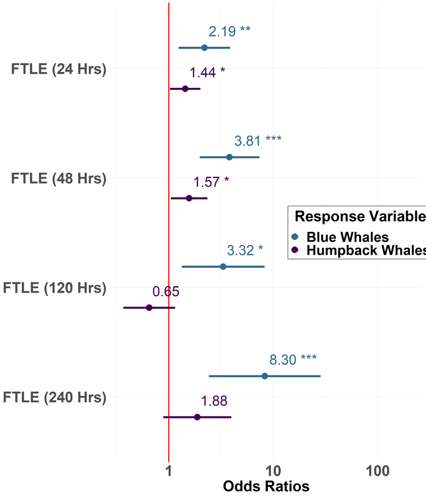

```r
# Plot the models together
  p_WhaleAll <- plot_models(bw_glmmPQL_24_Hrs,bw_glmmPQL_48_Hrs,bw_glmmPQL_120_Hrs,bw_glmmPQL_240_Hrs,
                            mn_glmmPQL_24_Hrs,mn_glmmPQL_48_Hrs,mn_glmmPQL_120_Hrs,mn_glmmPQL_240_Hrs,
                            vline.color = "red",show.p=TRUE,show.values=TRUE, spacing = .75,
                            #axis.lim = c(0.75,7.5),
                            show.legend = TRUE, dot.size = 6, value.size = 10, line.size = 2,
                            axis.labels = c("FTLE (240 Hrs)","FTLE (120 Hrs)","FTLE (48 Hrs)","FTLE (24 Hrs)")) +
    scale_y_log10( limits = c(-100,200))+
    theme_minimal() +
    theme(axis.title = element_text(face="bold", size=30),
          axis.text = element_text( face="bold", size=30),
          plot.title = element_text(face="bold", size=25,hjust = 0.5),
          plot.subtitle = element_text( face="bold", size=20,hjust = 0.5),
          plot.caption = element_text( face="bold", size=12,hjust = 0),
          legend.position = c(0.8,0.5),
          legend.direction = "vertical",
          legend.background = element_rect(fill="white",color="black"),
          legend.text = element_text(face="bold", size=28),
          legend.title = element_text(face="bold", size=30, hjust = 0.5))

  p_WhaleAll$guides$colour$title <- "Response Variable"

  p_WhaleAll$data$group <- factor(x = c(rep("Blue Whales",4), rep("Humpback Whales",4)), levels = c("Humpback Whales" , "Blue Whales") )
  p_WhaleAll <- p_WhaleAll + scale_color_manual(values=c( "Humpback Whales" =  "#440154FF",
                                                          "Blue Whales" =  "#31688EFF"
  ) )
  p_WhaleAll
```

## Results Table

```r
resultsT <- rbind(tssSigmaT_GLMM, tD10_GLMM, tD20_GLMM,tD30_GLMM,tD40_GLMM, tD50_GLMM,
                  tSigma25_GLMM,tSigma25_5_GLMM,tSigma26_GLMM,
                  tKrillPres,tgMNZGLMMPQLLogLink,tMNZGLMMPQLLogLink,tMaxGLMMPQLLogLink,
                  tBW,tHW)
resultsT_wide <- resultsT %>%
  pivot_wider(names_from = FTLE_Integration,values_from = Slope:pValue) %>%
  dplyr::select(1,2,6,10,3,7,11,4,8,12,5,9,13)
write_csv(resultsT_wide,"./Output/Table2-Results.csv"   )
kable(resultsT,row.names = FALSE,longtable=T) %>%
  kable_styling(latex_options=c("striped","repeat_header", "scale_down"))
```

| Model | FTLE_Integration | Slope | Intercept | pValue |
| --- | --- | --- | --- | --- |
| GLMM Sea Surface Sigma Theta | 24 | 0.0545 | 25.1968 | 0.52495 |
| GLMM Sea Surface Sigma Theta | 48 | 0.1262 | 25.1935 | 0.18939 |
| GLMM Sea Surface Sigma Theta | 120 | 0.3704 | 25.2281 | 0.00143 |
| GLMM Sea Surface Sigma Theta | 240 | 0.2889 | 25.2592 | 0.05069 |
| GLMM Sigma Theta at 10 meters | 24 | 0.0162 | 25.3555 | 0.84426 |
| GLMM Sigma Theta at 10 meters | 48 | 0.1176 | 25.3452 | 0.19947 |
| GLMM Sigma Theta at 10 meters | 120 | 0.3391 | 25.3673 | 0.00154 |
| GLMM Sigma Theta at 10 meters | 240 | 0.2454 | 25.3987 | 0.06771 |
| GLMM Sigma Theta at 20 meters | 24 | -0.1717 | 25.5993 | 0.01471 |
| GLMM Sigma Theta at 20 meters | 48 | -0.0335 | 25.5727 | 0.66812 |
| GLMM Sigma Theta at 20 meters | 120 | 0.1635 | 25.5819 | 0.06603 |
| GLMM Sigma Theta at 20 meters | 240 | 0.1611 | 25.6163 | 0.14203 |
| GLMM Sigma Theta at 30 meters | 24 | -0.1743 | 25.7775 | 0.00438 |
| GLMM Sigma Theta at 30 meters | 48 | -0.0826 | 25.7596 | 0.22734 |
| GLMM Sigma Theta at 30 meters | 120 | 0.0776 | 25.7667 | 0.31705 |
| GLMM Sigma Theta at 30 meters | 240 | 0.1415 | 25.7955 | 0.15451 |
| GLMM Sigma Theta at 40 meters | 24 | -0.1408 | 25.8791 | 0.00939 |
| GLMM Sigma Theta at 40 meters | 48 | -0.0418 | 25.8598 | 0.49531 |
| GLMM Sigma Theta at 40 meters | 120 | 0.0912 | 25.8721 | 0.19005 |
| GLMM Sigma Theta at 40 meters | 240 | 0.1367 | 25.8948 | 0.12618 |
| GLMM Sigma Theta at 50 meters | 24 | -0.1295 | 25.9706 | 0.00539 |
| GLMM Sigma Theta at 50 meters | 48 | -0.0282 | 25.9507 | 0.59256 |
| GLMM Sigma Theta at 50 meters | 120 | 0.0674 | 25.9653 | 0.26360 |
| GLMM Sigma Theta at 50 meters | 240 | 0.0962 | 25.9782 | 0.21549 |
| GLMM Depth of SigmaTheta 25 | 24 | 0.9432 | 8.1158 | 0.59605 |
| GLMM Depth of SigmaTheta 25 | 48 | -0.2272 | 8.1384 | 0.90861 |
| GLMM Depth of SigmaTheta 25 | 120 | -1.3907 | 7.4396 | 0.49282 |
| GLMM Depth of SigmaTheta 25 | 240 | -3.1431 | 6.6889 | 0.19746 |
| GLMM Depth of SigmaTheta 25.5 | 24 | 4.5977 | 19.4710 | 0.18006 |
| GLMM Depth of SigmaTheta 25.5 | 48 | -0.6020 | 20.3434 | 0.87680 |
| GLMM Depth of SigmaTheta 25.5 | 120 | -10.0798 | 18.7888 | 0.02193 |
| GLMM Depth of SigmaTheta 25.5 | 240 | -16.2146 | 17.6131 | 0.00341 |
| GLMM Depth of SigmaTheta 26 | 24 | 14.1729 | 48.5953 | 0.00564 |
| GLMM Depth of SigmaTheta 26 | 48 | 3.8680 | 50.5918 | 0.49933 |
| GLMM Depth of SigmaTheta 26 | 120 | -6.0794 | 50.3184 | 0.38792 |
| GLMM Depth of SigmaTheta 26 | 240 | -8.9667 | 49.7587 | 0.32645 |
| Krill Presence ~ FTLE | 24 | -0.3840 | 0.0780 | 0.01416 |
| Krill Presence ~ FTLE | 48 | -0.2740 | 0.0210 | 0.13664 |
| Krill Presence ~ FTLE | 120 | 0.2630 | -0.1330 | 0.29013 |
| Krill Presence ~ FTLE | 240 | 0.2850 | -0.1730 | 0.36950 |
| GLMMPQL_LogLink KrillDensity_geoMeanNonZero | 24 | 0.2731 | 0.8225 | 0.08437 |
| GLMMPQL_LogLink KrillDensity_geoMeanNonZero | 48 | 0.3622 | 0.8165 | 0.05616 |
| GLMMPQL_LogLink KrillDensity_geoMeanNonZero | 120 | 0.8218 | 0.8196 | 0.00110 |
| GLMMPQL_LogLink KrillDensity_geoMeanNonZero | 240 | 0.9878 | 0.7580 | 0.00061 |
| GLMMPQL_LogLink KrillDensity_MeanNonZero | 24 | 0.2064 | 1.1619 | 0.18788 |
| GLMMPQL_LogLink KrillDensity_MeanNonZero | 48 | 0.4448 | 1.1128 | 0.01664 |
| GLMMPQL_LogLink KrillDensity_MeanNonZero | 120 | 0.9310 | 1.1037 | 0.00016 |
| GLMMPQL_LogLink KrillDensity_MeanNonZero | 240 | 0.9675 | 1.1212 | 0.00248 |
| GLMMPQL_LogLink KrillDensity_Max | 24 | 0.0676 | 1.9669 | 0.68640 |
| GLMMPQL_LogLink KrillDensity_Max | 48 | 0.4069 | 1.8880 | 0.04000 |
| GLMMPQL_LogLink KrillDensity_Max | 120 | 0.8840 | 1.8287 | 0.00085 |
| GLMMPQL_LogLink KrillDensity_Max | 240 | 0.8341 | 1.8129 | 0.01589 |
| BLWH Presence ~ FTLE | 24 | 0.7860 | -5.9200 | 0.00686 |
| BLWH Presence ~ FTLE | 48 | 1.3390 | -5.9910 | 0.00007 |
| BLWH Presence ~ FTLE | 120 | 1.2000 | -5.8280 | 0.01009 |
| BLWH Presence ~ FTLE | 240 | 2.1160 | -5.9750 | 0.00077 |
| HUWH Presence ~ FTLE | 24 | 0.3610 | -3.6260 | 0.03571 |
| HUWH Presence ~ FTLE | 48 | 0.4490 | -3.6050 | 0.02978 |
| HUWH Presence ~ FTLE | 120 | -0.4320 | -3.4770 | 0.13831 |
| HUWH Presence ~ FTLE | 240 | 0.6290 | -3.6040 | 0.10102 |

# References

- Matt K Gough, Ad Reniers, M. Josefina Olascoaga, Brian K Haus, Jamie MacMahan, Jeff Paduan, Chris Halle, (2016). *Lagrangian Coherent Structures in a coastal upwelling environment*. Continental Shelf Research, https://doi.org/10.1016/j.csr.2016.09.007
- Fahlbusch, J. A., Czapanskiy, M. F., Calambokidis, J., Cade, D. E., Abrahms, B., Hazen, E. L., & Goldbogen, J. A. (2022). *Blue whales increase feeding rates at fine-scale ocean features*. Proceedings of the Royal Society B, https://royalsocietypublishing.org/doi/full/10.1098/rspb.2022.1180